# Plotrix

Abstract

“Plotrix” published in R News.

## A package in the red light district of R

## The social science of statistics

It is firmly established that statistics can assist the deceptive, but less well recognized that it can also aid those practising one of the other ancient arts. Some statisticians do attain the position of courtesans to the mighty, where they may spurn the lowlier tasks of their trade. Most of us must entertain the whims of the paying customer.

Like many R users, I did not aspire to be a statistician. The combination of a bit of relevant talent and the disinclination of others led to my recruitment. Readers are probably well aware that legions of reluctant statisticians desperately scan their sometimes inadequate knowledge in the effort to produce what others with considerably less knowledge demand.

In this spirit I began to program the functions that were included in the initial version of **plotrix** (Lemon, 2006). Inspiration was found not only in my own efforts to use R as I had previously used other statistical or graphical packages, but in the pleas of others like me that found their way to the R help list. Commercial software has lent a sympathetic, if not always disinterested, ear to such requests. You want a 3D pie chart with clip art symbols floating in the transparent sectors and you get it, for a price. There is a strong desire for the conventional in the average consumer of statistics, even if the conventional is not the most informative.

I would like to introduce **plotrix** using three topics in plotting that have been the subject of some discussion on the R help list as well as a little parade of the functions.

### How to slice the pie

Consider the aforementioned pie chart. There have been several discussions upon the wisdom of using such illustrations, typically initiated by a query from an R user. Despite the limitations of the pie chart, they seem common. To test this impression, I asked our friend Google to inform me on the phrase “division of wealth” and then stepped through the listing until I found an illustration of this phrase. On the twelfth hit, there was … a pie chart (Ng, 2006). As an example of the way in which the **plotrix** package may be used, I reproduced it in Figure 1. The code I used is shown below.

```
x11(width=7, height=4)
par(mar=c(0,0,0,0), xpd=FALSE)
plot(0, xlim=c(-2,2.2), ylim=c(-1,1),
     xlab="", ylab="", type="n")
rect(-2.5, -1.5, 2.5, 1.5, col="#ffffcb")
wealth.pct<-c(41, 15, 9.4, 6.4, 4.8, 3.7,
              2.9, 2.4, 2, 1.6, 12.1)
sector.colors<-c("#fe0000", "#ffff00", "#0000fe",
                  "#ff00fe", "#00ffff", "#fc6866",
                  "#666632", "#d2ffff", "#fdffcd",
                  "#ffcb65", "#ffffff")
floating.pie(0, 0, wealth.pct, col=sector.colors,
              startpos=pi/2)
text(-1.55, 0.2,
     "wealth owned by the\nrichest one percent
     of the population")
text(-1.4, -0.9,
```

```
"wealth owned by the second
richest one percent")
segments(-0.65, -0.85, -0.3, -0.8)
text(1.3, -0.7, "by third richest percentile")
text(1.55, -0.45, "by fourth richest percentile")
text(1.65, -0.1, "by fifth richest percentile")
text(1.64, 0.12, "by sixth richest percentile")
text(1.66, 0.3, "by seventh richest percentile")
text(1.55, 0.43, "by eighth richest percentile")
text(1.47, 0.53, "by ninth richest percentile")
text(1.37, 0.62, "by tenth richest percentile")
text(1, 0.95,
"Wealth left to the remaining 90% of the
population")
text(1.3, 0.85,
"(those of us worth less than $8 million)")
segments(0.2, 0.9, 0.23, 0.85)
par(cex=0.7)
text(1, -0.95,
"Copyright 2001 by Freeman Ng and
Progressive Schoolhouse")
text(1, -1.02,
"(http://www.ProgressiveSchoolhouse.org)")
par(cex=1.5)
text(-2, 0.9, "How the Pie is Sliced", adj=0)
par(cex=1, mar=c(5, 4, 4, 2), xpd=TRUE)
```

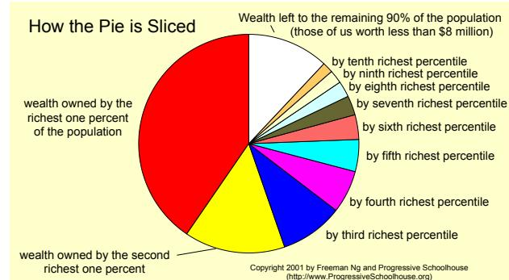

Figure 1: A reproduction of a pie chart

The R user can thus produce a reasonable approximation of this rather complicated chart. However, the beauty of the `floating.pie` function is not solely its ability to copy other people’s work. This chart is a good illustration of the major complaint about pie charts, our limited ability to translate the areas of circular sectors into relative quantities. The intent of the author was obviously to illustrate the concentration of private wealth in the USA in a minority. Compare the next chart, showing the relative wealth of the richest one percent, the rest of the top half and the poorest half of the population. Now it is easy to see that the richest one percent hold nearly half the wealth, the rest of the top half a bit more, and only a tiny slice is shared amongst the poorest half. The much more compact code is again below the figure.

### Another way to slice the pie

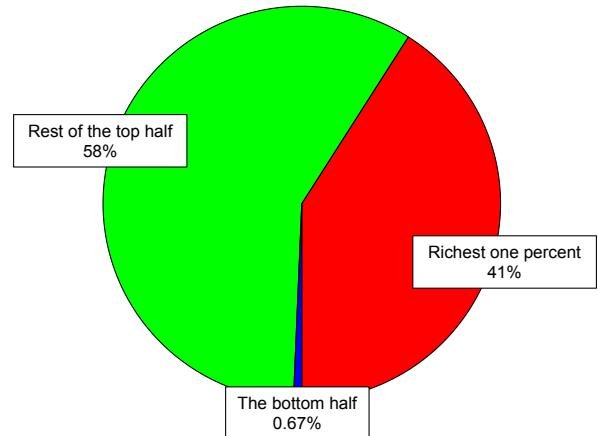

Figure 2: A reworked pie chart

```
par(xpd=NA, mar=c(2, 2, 2, 2))
plot(0, xlim=c(-1, 1), ylim=c(-1, 1), xlab="",
     ylab="", axes=FALSE, type="n")
wealth.pct <- c(41, 58.33, 0.67)
bisectors <- floating.pie(0, 0, wealth.pct,
                           radius=0.8,
                           startpos=3*pi/2)
pie.labels(0, 0, bisectors,
           c("Richest one percent\n41%",
             "Rest of the top half\n58%",
             "The bottom half\n0.67%"),
           radius=0.85, ypad=0.8)
par(cex=2)
text(0, 1, "Another way to slice the pie")
par(xpd=TRUE, mar=c(5, 4, 4, 2), cex=1)
```

It is clear that a pie chart with a small number of sectors can present a “big slice-little slice” distribution as a “sight bite.” `floating.pie` is intended to overlay small pie charts on other plots. Thus one could add a series of “top half/bottom half” pie charts to a plot of GNP by country to show how the distribution of wealth is related to GNP.

### How to bridge the gap

While `floating.pie` was only a modification of the existing `pie` function, many of the other plot variants were programmed from the bottom up, such as `pie3D`. Another vexed area in R is how to deal with empty space. When the values to be plotted are all very large or small, R will typically display only the range of those values. However, if the values fall into two groups, we will see the smaller values at the bottom, a large gap, and the larger values at the top of the resulting plot. The initial response to the former problem was the `axis.break` function. This displayed the conventional slash or zigzag break symbol on the axis chosen by the user.

`staxlab`, another function from **plotrix**, came to the rescue of the mountain names, as the “intelligent clipping” of the x-axis labels snipped two off. To fix this, empty names were passed, and then the labels were put in place. They didn’t really need to be staggered, but it was a good opportunity for `staxlab` to show off.

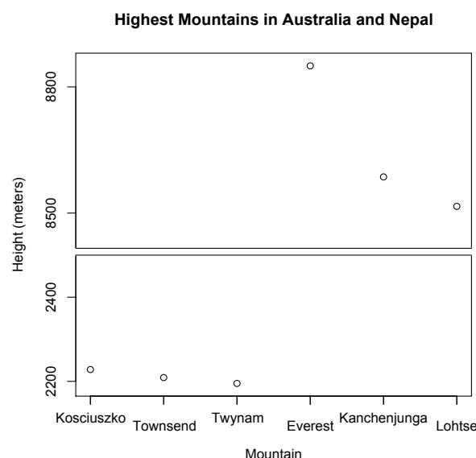

Figure 3: Australia vs Nepal

```
mountains<-c(2228, 2209, 2195, 8850, 8586, 8516)
gap.plot(mountains, gap.bounds=c(2500, 8400),
         gap.axis="y",
         xaxlab=c("", "", "", "", "", ""),
         xtics=1:6,
         ytics=c(2200, 2400, 8500, 8800),
         main=
         "Highest Mountains in Australia and
         Nepal",
         xlab="Mountain", ylab="Height (meters)")
staxlab(at=1:6,labels=c("Kosciuszko","Townsend",
                       "Twynam","Everest",
                       "Kanchenjunga","Lohtse"),
         nlines=2,top.line=0.8,line.spacing=0.5)
```

### How to appear 3D

Another topic that frequently appears on the R help list is the wisdom of trying to get more than two dimensions into a two dimensional illustration. I’ll use this to introduce `triax.plot` and its relatives. This function was originally programmed in response to a request for a “soil texture” plot in which the proportions or percentages of three arbitrary particle size categories are displayed. This is a particular example of the more general “triangle” plot. In response to another request, the function was completely rewritten as `triax.plot` and `soil.texture` became a restricted call to this function. Other capabilities were added, such as `triax.abline` allowing lines representing values on the axes to be added. While the triangle plot appears to show three value coordinates, it only works because the coordinates are not independent. The triplets must sum to 1 for proportions or 100 for percentages. `triax.plot` will output a warning if this condition is not satisfied. In contrast, `triangle.plot` in **ade4** (Penel, 2005) silently transforms each set of values to percentages. This may not be what the user intended in some cases, so `triax.plot` leaves the decision to transform to the user. The somewhat odd name is to avoid confusion with other triangle plot functions.

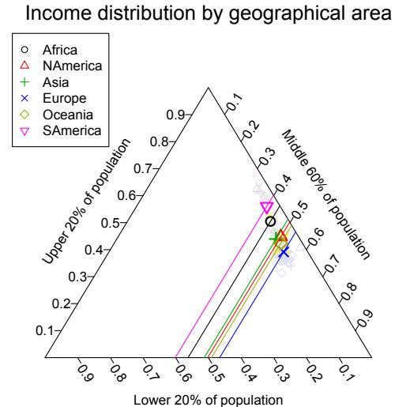

Figure 4: Income distribution in geographical areas

[output not shown]

Below is a list of most of the functions in **plotrix** v2.1, which should be the version available when you are reading this. Functions usually called by another function are not included.

```
axis.break
  Put a "break" in a plot axis
axis.mult
  Display an axis with a multiplier
barplot.symbol.default
  Barplot with bars filled with symbols
bin.wind.records
  Classify wind direction and speed records
boxed.labels
  Display text strings in boxes
clean.args
  Remove arguments that would cause an error
```

```
clock24.plot
  Plot values on a 24 hour "clockface"
cluster.overplot
  Display overlying points as clusters
color.id
  Find the closest color name to an RGB code
color.scale
  Transform numeric values into colors
color2D.matplot
  Display a numeric matrix as a color matrix
corner.label
  Display a label in one corner of a plot
count.overplot
  Display overlying points as a number
feather.plot
  Display vectors along a horizontal line
floating.pie
  Flat pie chart at a specified position
freq
  Calculate frequencies
gantt.chart
  Gantt chart with task priority colors
gap.barplot
  Barplot with a range of values omitted
gap.plot
  Plot with a range of values omitted
get.gantt.info
  Enter information for a Gantt chart
get.soil.texture
  Enter information for soil textures
get.triprop
  Enter triplets of proportions or percentages
multhist
  Plot a multiple histogram as a barplot
multsymbolbox
  Boxes filled with symbols representing counts
oz.windrose
  Australian BOM wind rose
pie3D
  Display a 3D pie chart
plot.freq
  Horizontal barplot of frequencies
plotCI
  Display confidence intervals/error bars
polar.plot
  Plot values on a 0-360 degree scale
polygon.shadow
  Display a shadow effect for a polygon
print.freq
  Display frequency tables
radial.plot
  Plot values on a 0-2*pi radian scale
remove.args
  Remove specified arguments from a list
sizeplot
  Display overlying points as larger points
smoothColors
  Build a vector of interpolated colors
soil.texture
  Display a "soil texture triangle"
spread.labels
  Spread out labels for values
staxlab
  Display staggered labels on an axis
```

`symbolbox`  
Draw a box filled with symbols  
`textbox`  
Display justified text in an optional box  
`thigmophobe.labels`  
Place labels away from the nearest other point  
`triax.plot`  
Display a triangle (three axis) plot

The proliferation of packages and functions for R has led to many similar functions in different packages. The `radial.plot` family, including `radial.plot`, `polar.plot` and `clock24.plot` has relatives including `rosavent` in **climatol**, (Guijarro, 2004) `plot.circular` in **circular** (Agostinelli, 2005) and `rose.diag` in **CircStats** (Agostinelli, 2005). The presence of similar functions in different packages that give the user more choices leads to the ensuing difficulty of finding the functions that afford the choices. There have been several attempts to minimize the latter effect. My own favorite is arbitrary text searching such as that implemented by Professor Jonathon Baron’s R Site Search facility (Baron, 2006).

## A parting glance at style

**plotrix** has a strong collaborative influence, and it is hoped that this will continue. The programming style leans toward the explicit rather than being highly condensed or efficient, and many R users have contributed not only suggestions but segments of code that have been incorporated. Those experienced in the more arcane techniques of illustration have offered valuable comments on improving certain functions. The overall utility of **plotrix** is largely a product of this expert feedback. A possible extension of **plotrix** would be to add compatibility with the more flexible **grid** package plotting functions.

The aim of **plotrix** is not to erode the high standards of R but to allow its users to perform the more mundane tasks of their calling with less effort. The consumer who accepts that R can produce the comforting pictures to which he or she is accustomed may well be seduced into the more challenging illustrations of data. It is hoped that **plotrix** and similar packages will provide functions that allow the new user to demonstrate the basic capabilities of R as rapidly as any other statistical software and the experienced user to generate the common varieties of data illustration more conveniently.

## References

- C. Agostinelli. *circular: Circular statistics*. URL http://cran.r-project.org/src/contrib/Descriptions/CircStats.html
- C. Agostinelli. *CircStats: Circular statistics*. URL http://cran.r-project.org/src/contrib/Descriptions/circular.html
- J. Baron. *R Site Search* URL http://finzi.psych.upenn.edu/search.html
- K.W. Deininger. *Measuring Income Inequality Database*. URL http://siteresources.worldbank.org/INTRES/Resources/469232-1107449512766/648083-1108140788422/A_New_Dataset_Measuring_Income_Inequality.zip
- J.A. Guijarro. *Climatol: some tools for climatology*. URL http://cran.r-project.org/src/contrib/Descriptions/climatol.html
- J. Lemon. *plotrix: Various plotting functions*. URL http://cran.r-project.org/src/contrib/Descriptions/plotrix.html
- F. Ng. *The Division of Wealth* URL http://www.progressiveschoolhouse.org/wealth/wealthdivisions.htm
- S. Penel. *ade4: Multivariate data analysis and graphical display*. URL http://cran.r-project.org/src/contrib/Descriptions/ade4.html